# Financial Securities Summary

- **By:** David G. Johnston (david.g.johnston@gmail.com)
- **GitHub:** polobo/FinancialSecuritiesSummary

## Limitations

Name resolution is currently an in-progress work. If the supplied security has a ticker symbol that Yahoo! can resolve a length-limited name will be returned by that service and the FinancialInstrument database addition should suceed with adding the security as a `stock` type. This applies to at least some Vanguard mutual funds.

Within the `updateFIDatabase` function you can add entries to a symbol/name override routine and these will then be displayed throughout the rest of the documentation.

Spent way too much time trying to figure out how to suppress the `[1] "Symbol Name"` output from the Yahoo! meta-data lookup in FI. Seems to an unfavorable interaction between `knitr` and `FinancialInstruments`.

“USD” is hard-coded as the currency.

## Portfolio

```r
# Here we actually identify the securities to print
displaySymbol("VCR")
```

```
## [1] "Vanguard Consumer Discretion ET"
## Yahoo! Resolved VCR to Vanguard Consumer Discretion ET
## Vangaurd Consumer Discretionary ETF [VCR]
## EMA200: 113.97
## CLOSE : 121.76 ( 6.83 % )
```

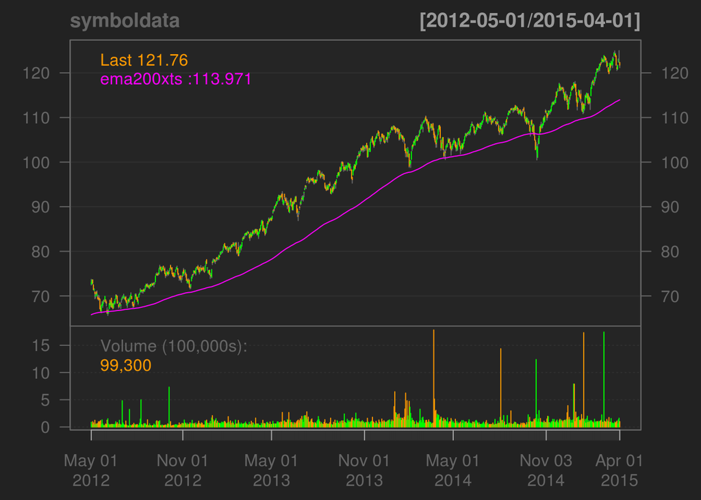

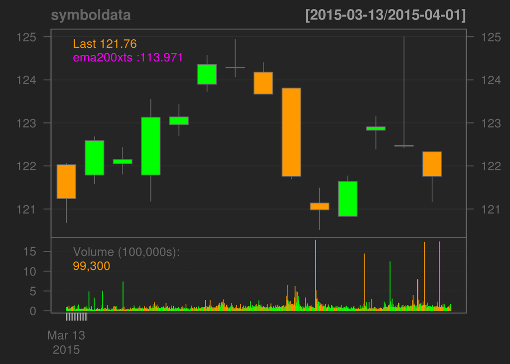

```r
displaySymbol("VFH")
```

```
## [1] "Vanguard Financials ETF - DNQ"
## Yahoo! Resolved VFH to Vanguard Financials ETF - DNQ
## Vanguard Financials ETF - DNQ
## EMA200: 47.77
## CLOSE : 49.24 ( 3.09 % )
```

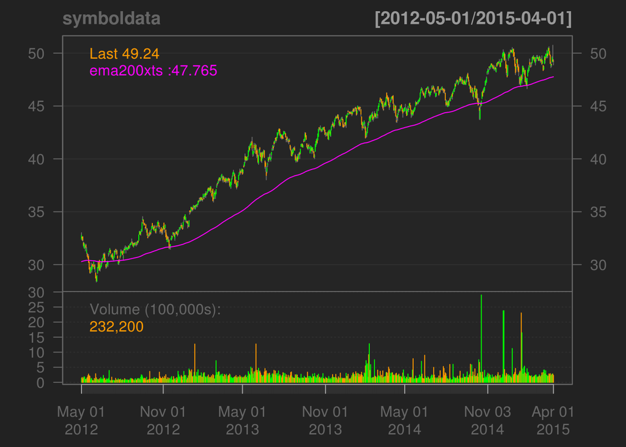

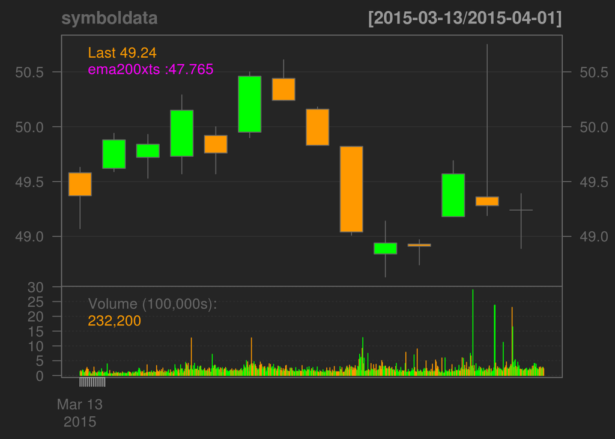

```r
displaySymbol("VIS")
```

```
## [1] "Vanguard Industrials ETF - DNQ"
## Yahoo! Resolved VIS to Vanguard Industrials ETF - DNQ
## Vanguard Industrials ETF - DNQ
## EMA200: 104.43
## CLOSE : 106.42 ( 1.9 % )
```

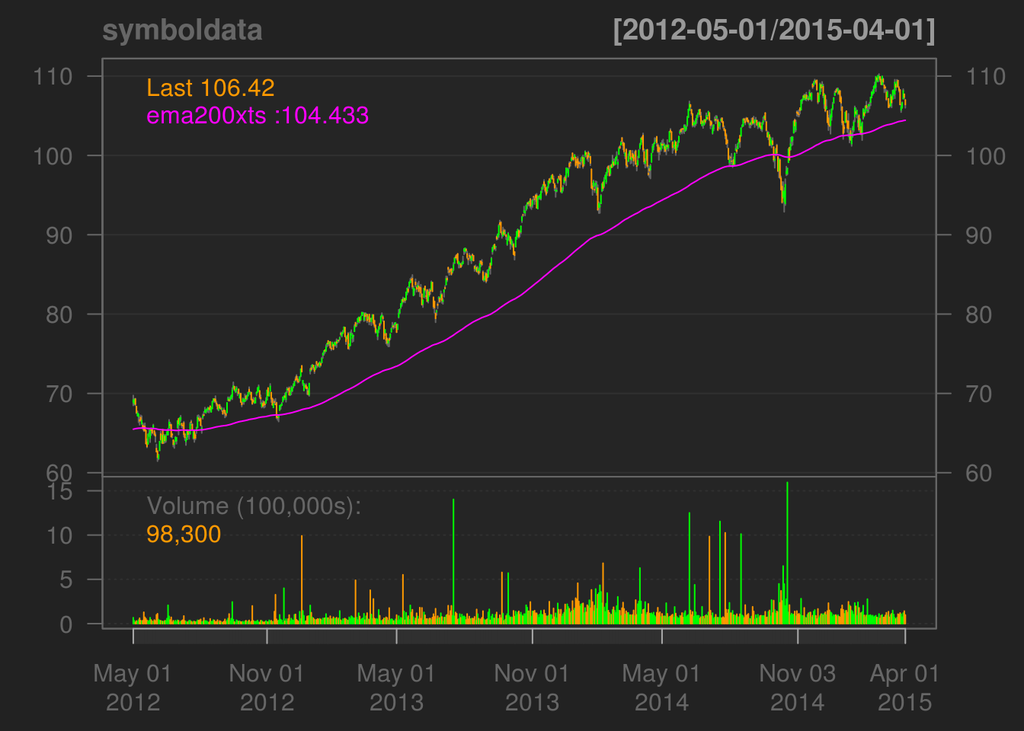

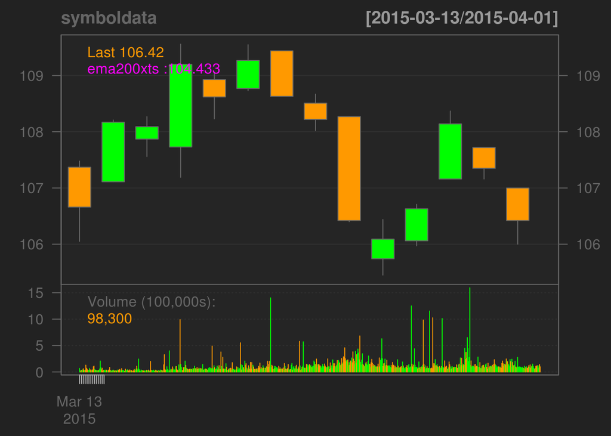

## Watch List

```r
displaySymbol("VNQ")
```

```
## [1] "Vanguard REIT ETF - DNQ"
## Yahoo! Resolved VNQ to Vanguard REIT ETF - DNQ
## Vanguard REIT ETF - DNQ
## EMA200: 79.93
## CLOSE : 84.19 ( 5.34 % )
```

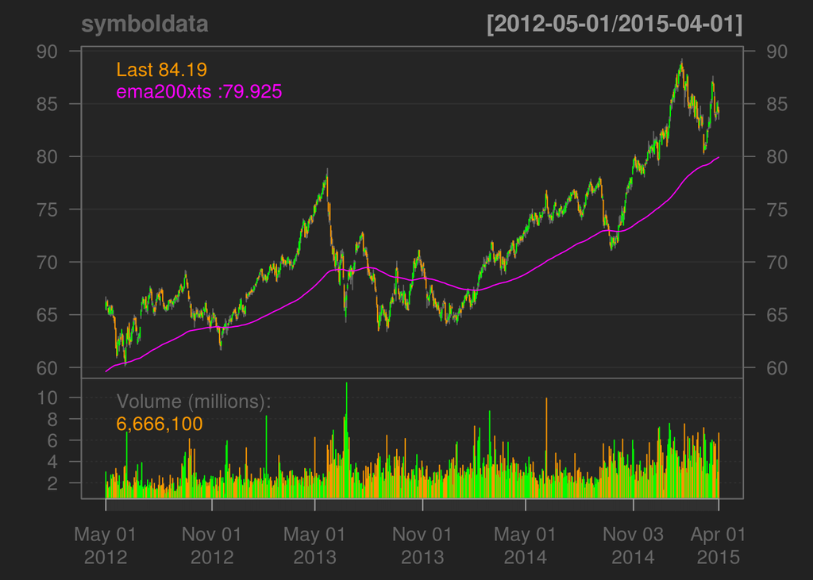

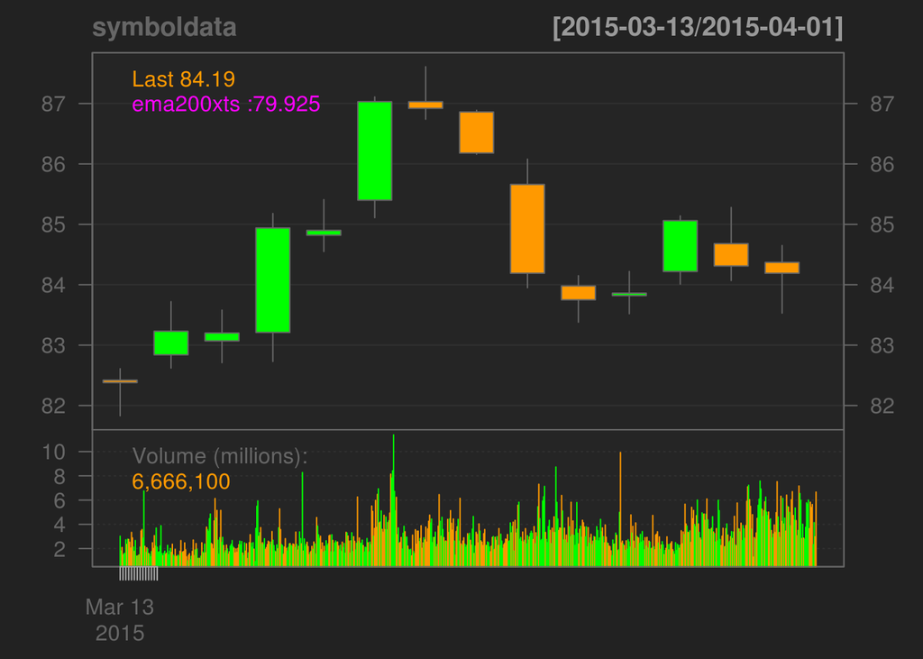

```r
displaySymbol("VAW")
```

```
## [1] "Vanguard Materials ETF - DNQ"
## Yahoo! Resolved VAW to Vanguard Materials ETF - DNQ
## Vanguard Materials ETF - DNQ
## EMA200: 108.18
## CLOSE : 108.45 ( 0.25 % )
```

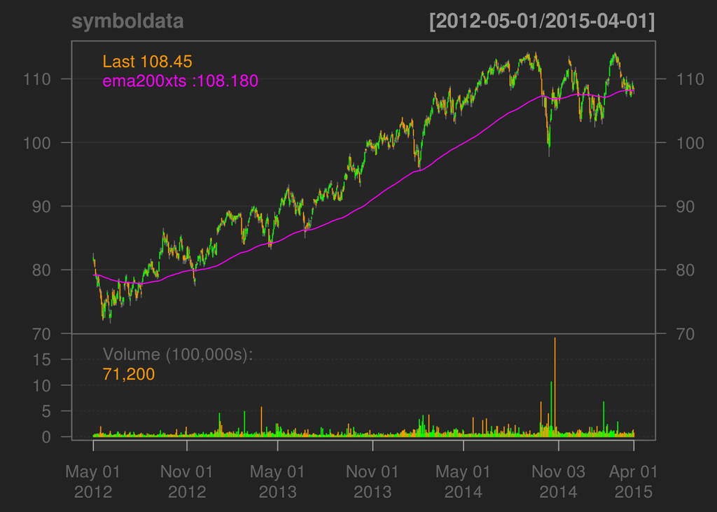

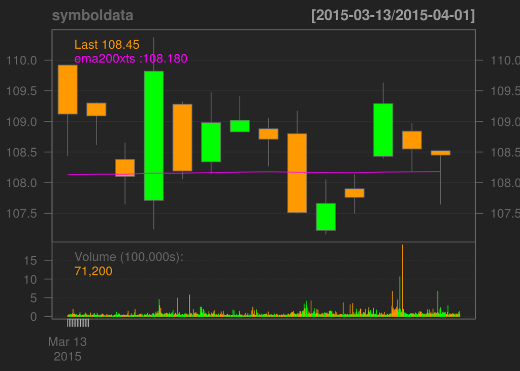

```r
displaySymbol("VDE")
```

```
## [1] "Vanguard Energy ETF"
## Yahoo! Resolved VDE to Vanguard Energy ETF
## Vanguard Energy ETF
## EMA200: 118.41
## CLOSE : 109.54 ( -7.49 % )
```

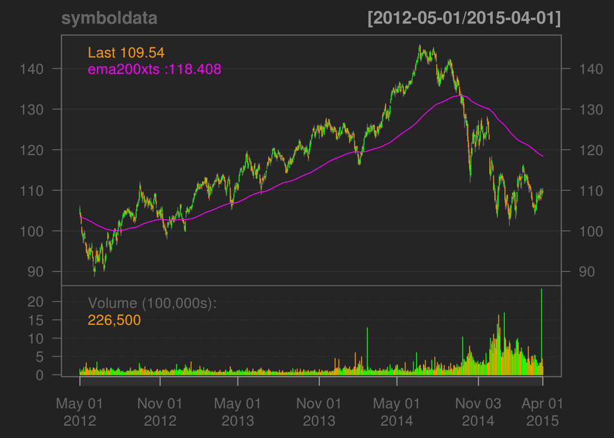

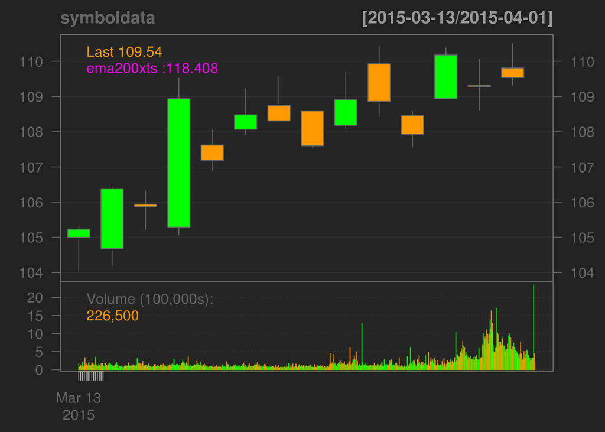

```r
displaySymbol("VOX")
```

```
## [1] "Vanguard Telecom ETF - DNQ"
## Yahoo! Resolved VOX to Vanguard Telecom ETF - DNQ
## Vanguard Telecom ETF - DNQ
## EMA200: 86.46
## CLOSE : 87.83 ( 1.59 % )
```

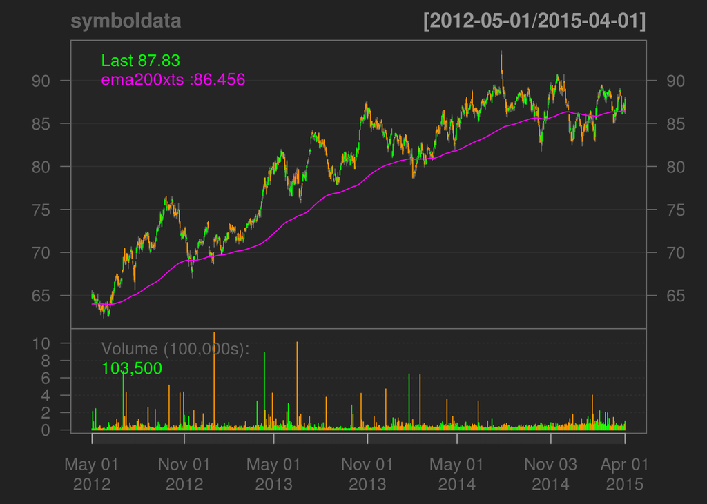

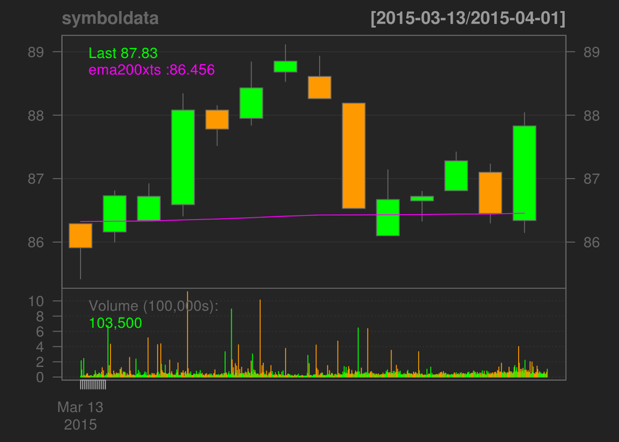

## Summary

Now that individual securities have been described we can gather up the contents of FinancialInstruments database and the attached attributes and xts objects to create an online table and/or a CSV file which can be copied into a custom Excel model for additional manipulation. Eventually some of the Excel stuff will probably migrate to here…

**Not Implemented Yet!**